# Risk Factor Analysis

## Outcome Variable

**Outcome Variable:** y_rate_haz

## Predictor Variables

**Intervention Variable:** predfeed6

**Adjustment Set:**

- arm
- sex
- month
- brthmon
- W_mage
- meducyrs
- feducyrs
- hhwealth_quart
- hfoodsec
- W_mhtcm
- W_mwtkg
- W_mbmi
- vagbrth
- W_birthwt
- W_birthlen
- single
- W_nrooms
- impfloor
- impsan
- safeh20
- delta_W_mage
- delta_meducyrs
- delta_feducyrs
- delta_hhwealth_quart
- delta_hfoodsec
- delta_W_mhtcm
- delta_W_mwtkg
- delta_W_mbmi
- delta_vagbrth
- delta_W_birthwt
- delta_W_birthlen
- delta_single
- delta_W_nrooms
- delta_impfloor
- delta_impsan
- delta_safeh20

## Stratifying Variables

The analysis was stratified on these variable(s):

- agecat
- studyid
- country

## Data Summary

| agecat | studyid | country | predfeed6 | n_cell | n | outcome_variable |
| --- | --- | --- | --- | --- | --- | --- |
| 0-3 months | ki0047075b-MAL-ED | BANGLADESH | 1 | 82 | 227 | y_rate_haz |
| 0-3 months | ki0047075b-MAL-ED | BANGLADESH | 0 | 145 | 227 | y_rate_haz |
| 0-3 months | ki0047075b-MAL-ED | BRAZIL | 1 | 21 | 163 | y_rate_haz |
| 0-3 months | ki0047075b-MAL-ED | BRAZIL | 0 | 142 | 163 | y_rate_haz |
| 0-3 months | ki0047075b-MAL-ED | INDIA | 1 | 8 | 167 | y_rate_haz |
| 0-3 months | ki0047075b-MAL-ED | INDIA | 0 | 159 | 167 | y_rate_haz |
| 0-3 months | ki0047075b-MAL-ED | NEPAL | 1 | 11 | 145 | y_rate_haz |
| 0-3 months | ki0047075b-MAL-ED | NEPAL | 0 | 134 | 145 | y_rate_haz |
| 0-3 months | ki0047075b-MAL-ED | PERU | 1 | 85 | 254 | y_rate_haz |
| 0-3 months | ki0047075b-MAL-ED | PERU | 0 | 169 | 254 | y_rate_haz |
| 0-3 months | ki0047075b-MAL-ED | SOUTH AFRICA | 1 | 2 | 186 | y_rate_haz |
| 0-3 months | ki0047075b-MAL-ED | SOUTH AFRICA | 0 | 184 | 186 | y_rate_haz |
| 0-3 months | ki0047075b-MAL-ED | TANZANIA, UNITED REPUBLIC OF | 1 | 0 | 211 | y_rate_haz |
| 0-3 months | ki0047075b-MAL-ED | TANZANIA, UNITED REPUBLIC OF | 0 | 211 | 211 | y_rate_haz |
| 0-3 months | ki1000109-EE | PAKISTAN | 1 | 33 | 37 | y_rate_haz |
| 0-3 months | ki1000109-EE | PAKISTAN | 0 | 4 | 37 | y_rate_haz |
| 0-3 months | ki1113344-GMS-Nepal | NEPAL | 1 | 368 | 501 | y_rate_haz |
| 0-3 months | ki1113344-GMS-Nepal | NEPAL | 0 | 133 | 501 | y_rate_haz |
| 0-3 months | kiGH5241-JiVitA-3 | BANGLADESH | 1 | 9260 | 11961 | y_rate_haz |
| 0-3 months | kiGH5241-JiVitA-3 | BANGLADESH | 0 | 2701 | 11961 | y_rate_haz |
| 0-3 months | kiGH5241-JiVitA-4 | BANGLADESH | 1 | 2064 | 2466 | y_rate_haz |
| 0-3 months | kiGH5241-JiVitA-4 | BANGLADESH | 0 | 402 | 2466 | y_rate_haz |
| 3-6 months | ki0047075b-MAL-ED | BANGLADESH | 1 | 80 | 222 | y_rate_haz |
| 3-6 months | ki0047075b-MAL-ED | BANGLADESH | 0 | 142 | 222 | y_rate_haz |
| 3-6 months | ki0047075b-MAL-ED | BRAZIL | 1 | 30 | 208 | y_rate_haz |
| 3-6 months | ki0047075b-MAL-ED | BRAZIL | 0 | 178 | 208 | y_rate_haz |
| 3-6 months | ki0047075b-MAL-ED | INDIA | 1 | 11 | 213 | y_rate_haz |
| 3-6 months | ki0047075b-MAL-ED | INDIA | 0 | 202 | 213 | y_rate_haz |
| 3-6 months | ki0047075b-MAL-ED | NEPAL | 1 | 11 | 222 | y_rate_haz |
| 3-6 months | ki0047075b-MAL-ED | NEPAL | 0 | 211 | 222 | y_rate_haz |

[output cut: 150 more lines]

The following strata were considered:

- agecat: 0-3 months, studyid: ki0047075b-MAL-ED, country: BANGLADESH
- agecat: 0-3 months, studyid: ki0047075b-MAL-ED, country: BRAZIL
- agecat: 0-3 months, studyid: ki0047075b-MAL-ED, country: INDIA
- agecat: 0-3 months, studyid: ki0047075b-MAL-ED, country: NEPAL
- agecat: 0-3 months, studyid: ki0047075b-MAL-ED, country: PERU
- agecat: 0-3 months, studyid: ki0047075b-MAL-ED, country: SOUTH AFRICA
- agecat: 0-3 months, studyid: ki0047075b-MAL-ED, country: TANZANIA, UNITED REPUBLIC OF
- agecat: 0-3 months, studyid: ki1000109-EE, country: PAKISTAN
- agecat: 0-3 months, studyid: ki1113344-GMS-Nepal, country: NEPAL
- agecat: 0-3 months, studyid: kiGH5241-JiVitA-3, country: BANGLADESH
- agecat: 0-3 months, studyid: kiGH5241-JiVitA-4, country: BANGLADESH
- agecat: 12-15 months, studyid: ki0047075b-MAL-ED, country: BANGLADESH
- agecat: 12-15 months, studyid: ki0047075b-MAL-ED, country: BRAZIL
- agecat: 12-15 months, studyid: ki0047075b-MAL-ED, country: INDIA
- agecat: 12-15 months, studyid: ki0047075b-MAL-ED, country: NEPAL
- agecat: 12-15 months, studyid: ki0047075b-MAL-ED, country: PERU
- agecat: 12-15 months, studyid: ki0047075b-MAL-ED, country: SOUTH AFRICA
- agecat: 12-15 months, studyid: ki0047075b-MAL-ED, country: TANZANIA, UNITED REPUBLIC OF
- agecat: 12-15 months, studyid: ki1000109-EE, country: PAKISTAN
- agecat: 12-15 months, studyid: ki1000304b-SAS-FoodSuppl, country: INDIA
- agecat: 12-15 months, studyid: ki1113344-GMS-Nepal, country: NEPAL
- agecat: 12-15 months, studyid: ki1148112-LCNI-5, country: MALAWI
- agecat: 12-15 months, studyid: kiGH5241-JiVitA-4, country: BANGLADESH
- agecat: 15-18 months, studyid: ki0047075b-MAL-ED, country: BANGLADESH
- agecat: 15-18 months, studyid: ki0047075b-MAL-ED, country: BRAZIL
- agecat: 15-18 months, studyid: ki0047075b-MAL-ED, country: INDIA
- agecat: 15-18 months, studyid: ki0047075b-MAL-ED, country: NEPAL
- agecat: 15-18 months, studyid: ki0047075b-MAL-ED, country: PERU
- agecat: 15-18 months, studyid: ki0047075b-MAL-ED, country: SOUTH AFRICA
- agecat: 15-18 months, studyid: ki0047075b-MAL-ED, country: TANZANIA, UNITED REPUBLIC OF
- agecat: 15-18 months, studyid: ki1000109-EE, country: PAKISTAN
- agecat: 15-18 months, studyid: ki1000304b-SAS-FoodSuppl, country: INDIA
- agecat: 15-18 months, studyid: ki1113344-GMS-Nepal, country: NEPAL
- agecat: 15-18 months, studyid: ki1148112-LCNI-5, country: MALAWI
- agecat: 15-18 months, studyid: kiGH5241-JiVitA-4, country: BANGLADESH
- agecat: 18-21 months, studyid: ki0047075b-MAL-ED, country: BANGLADESH
- agecat: 18-21 months, studyid: ki0047075b-MAL-ED, country: BRAZIL
- agecat: 18-21 months, studyid: ki0047075b-MAL-ED, country: INDIA
- agecat: 18-21 months, studyid: ki0047075b-MAL-ED, country: NEPAL
- agecat: 18-21 months, studyid: ki0047075b-MAL-ED, country: PERU
- agecat: 18-21 months, studyid: ki0047075b-MAL-ED, country: SOUTH AFRICA
- agecat: 18-21 months, studyid: ki0047075b-MAL-ED, country: TANZANIA, UNITED REPUBLIC OF
- agecat: 18-21 months, studyid: ki1000109-EE, country: PAKISTAN
- agecat: 18-21 months, studyid: ki1113344-GMS-Nepal, country: NEPAL
- agecat: 18-21 months, studyid: ki1148112-LCNI-5, country: MALAWI
- agecat: 21-24 months, studyid: ki0047075b-MAL-ED, country: BANGLADESH
- agecat: 21-24 months, studyid: ki0047075b-MAL-ED, country: BRAZIL
- agecat: 21-24 months, studyid: ki0047075b-MAL-ED, country: INDIA
- agecat: 21-24 months, studyid: ki0047075b-MAL-ED, country: NEPAL
- agecat: 21-24 months, studyid: ki0047075b-MAL-ED, country: PERU
- agecat: 21-24 months, studyid: ki0047075b-MAL-ED, country: SOUTH AFRICA
- agecat: 21-24 months, studyid: ki0047075b-MAL-ED, country: TANZANIA, UNITED REPUBLIC OF
- agecat: 21-24 months, studyid: ki1000109-EE, country: PAKISTAN
- agecat: 21-24 months, studyid: ki1113344-GMS-Nepal, country: NEPAL
- agecat: 21-24 months, studyid: ki1148112-LCNI-5, country: MALAWI
- agecat: 3-6 months, studyid: ki0047075b-MAL-ED, country: BANGLADESH
- agecat: 3-6 months, studyid: ki0047075b-MAL-ED, country: BRAZIL
- agecat: 3-6 months, studyid: ki0047075b-MAL-ED, country: INDIA
- agecat: 3-6 months, studyid: ki0047075b-MAL-ED, country: NEPAL
- agecat: 3-6 months, studyid: ki0047075b-MAL-ED, country: PERU
- agecat: 3-6 months, studyid: ki0047075b-MAL-ED, country: SOUTH AFRICA
- agecat: 3-6 months, studyid: ki0047075b-MAL-ED, country: TANZANIA, UNITED REPUBLIC OF
- agecat: 3-6 months, studyid: ki1000109-EE, country: PAKISTAN
- agecat: 3-6 months, studyid: ki1113344-GMS-Nepal, country: NEPAL
- agecat: 3-6 months, studyid: kiGH5241-JiVitA-3, country: BANGLADESH
- agecat: 3-6 months, studyid: kiGH5241-JiVitA-4, country: BANGLADESH
- agecat: 6-9 months, studyid: ki0047075b-MAL-ED, country: BANGLADESH
- agecat: 6-9 months, studyid: ki0047075b-MAL-ED, country: BRAZIL
- agecat: 6-9 months, studyid: ki0047075b-MAL-ED, country: INDIA
- agecat: 6-9 months, studyid: ki0047075b-MAL-ED, country: NEPAL
- agecat: 6-9 months, studyid: ki0047075b-MAL-ED, country: PERU
- agecat: 6-9 months, studyid: ki0047075b-MAL-ED, country: SOUTH AFRICA
- agecat: 6-9 months, studyid: ki0047075b-MAL-ED, country: TANZANIA, UNITED REPUBLIC OF
- agecat: 6-9 months, studyid: ki1000109-EE, country: PAKISTAN
- agecat: 6-9 months, studyid: ki1000304b-SAS-FoodSuppl, country: INDIA
- agecat: 6-9 months, studyid: ki1113344-GMS-Nepal, country: NEPAL
- agecat: 6-9 months, studyid: ki1148112-LCNI-5, country: MALAWI
- agecat: 6-9 months, studyid: kiGH5241-JiVitA-4, country: BANGLADESH
- agecat: 9-12 months, studyid: ki0047075b-MAL-ED, country: BANGLADESH
- agecat: 9-12 months, studyid: ki0047075b-MAL-ED, country: BRAZIL
- agecat: 9-12 months, studyid: ki0047075b-MAL-ED, country: INDIA
- agecat: 9-12 months, studyid: ki0047075b-MAL-ED, country: NEPAL
- agecat: 9-12 months, studyid: ki0047075b-MAL-ED, country: PERU
- agecat: 9-12 months, studyid: ki0047075b-MAL-ED, country: SOUTH AFRICA
- agecat: 9-12 months, studyid: ki0047075b-MAL-ED, country: TANZANIA, UNITED REPUBLIC OF
- agecat: 9-12 months, studyid: ki1000109-EE, country: PAKISTAN
- agecat: 9-12 months, studyid: ki1000304b-SAS-FoodSuppl, country: INDIA
- agecat: 9-12 months, studyid: ki1113344-GMS-Nepal, country: NEPAL
- agecat: 9-12 months, studyid: ki1148112-LCNI-5, country: MALAWI
- agecat: 9-12 months, studyid: kiGH5241-JiVitA-4, country: BANGLADESH

### Dropped Strata

Some strata were dropped due to rare outcomes:

- agecat: 0-3 months, studyid: ki0047075b-MAL-ED, country: SOUTH AFRICA
- agecat: 0-3 months, studyid: ki0047075b-MAL-ED, country: TANZANIA, UNITED REPUBLIC OF
- agecat: 0-3 months, studyid: ki1000109-EE, country: PAKISTAN
- agecat: 3-6 months, studyid: ki0047075b-MAL-ED, country: SOUTH AFRICA
- agecat: 3-6 months, studyid: ki0047075b-MAL-ED, country: TANZANIA, UNITED REPUBLIC OF
- agecat: 3-6 months, studyid: ki1000109-EE, country: PAKISTAN
- agecat: 6-9 months, studyid: ki0047075b-MAL-ED, country: SOUTH AFRICA
- agecat: 6-9 months, studyid: ki0047075b-MAL-ED, country: TANZANIA, UNITED REPUBLIC OF
- agecat: 6-9 months, studyid: ki1000304b-SAS-FoodSuppl, country: INDIA
- agecat: 9-12 months, studyid: ki0047075b-MAL-ED, country: SOUTH AFRICA
- agecat: 9-12 months, studyid: ki0047075b-MAL-ED, country: TANZANIA, UNITED REPUBLIC OF
- agecat: 9-12 months, studyid: ki1000304b-SAS-FoodSuppl, country: INDIA
- agecat: 12-15 months, studyid: ki0047075b-MAL-ED, country: SOUTH AFRICA
- agecat: 12-15 months, studyid: ki0047075b-MAL-ED, country: TANZANIA, UNITED REPUBLIC OF
- agecat: 12-15 months, studyid: ki1000304b-SAS-FoodSuppl, country: INDIA
- agecat: 12-15 months, studyid: ki1148112-LCNI-5, country: MALAWI
- agecat: 15-18 months, studyid: ki0047075b-MAL-ED, country: SOUTH AFRICA
- agecat: 15-18 months, studyid: ki0047075b-MAL-ED, country: TANZANIA, UNITED REPUBLIC OF
- agecat: 15-18 months, studyid: ki1000304b-SAS-FoodSuppl, country: INDIA
- agecat: 15-18 months, studyid: ki1148112-LCNI-5, country: MALAWI
- agecat: 18-21 months, studyid: ki0047075b-MAL-ED, country: SOUTH AFRICA
- agecat: 18-21 months, studyid: ki0047075b-MAL-ED, country: TANZANIA, UNITED REPUBLIC OF
- agecat: 21-24 months, studyid: ki0047075b-MAL-ED, country: SOUTH AFRICA
- agecat: 21-24 months, studyid: ki0047075b-MAL-ED, country: TANZANIA, UNITED REPUBLIC OF
- agecat: 21-24 months, studyid: ki1000109-EE, country: PAKISTAN

## Methods Detail

We’re interested in the causal parameters $E[Y_a]$ for all values of $a \in \mathcal{A}$. These parameters represent the mean outcome if, possibly contrary to fact, we intervened to set all units to have $A=a$. Under the randomization and positivity assumptions, these are identified by the statistical parameters $\psi_a=E_W[E_{Y|A,W}(Y|A=a,W)]$. In addition, we’re interested in the mean of $Y$, $E[Y]$ under no intervention (the observed mean). We will estimate these parameters by using SuperLearner to fit the relevant likelihood factors – $E_{Y|A,W}(Y|A=a,W)$ and $p(A=a|W)$, and then updating our likelihood fit using a joint TMLE.

For unadjusted analyses ($W=\{\}$), initial likelihoods were estimated using Lrnr_glm to estimate the simple $E(Y|A)$ and Lrnr_mean to estimate $p(A)$. For adjusted analyses, a small library containing Lrnr_glmnet, Lrnr_xgboost, and Lrnr_mean was used.

Having estimated these parameters, we will then use the delta method to estimate relative risks and attributable risks relative to a prespecified baseline level of $A$.

# Results Detail

## Results Plots

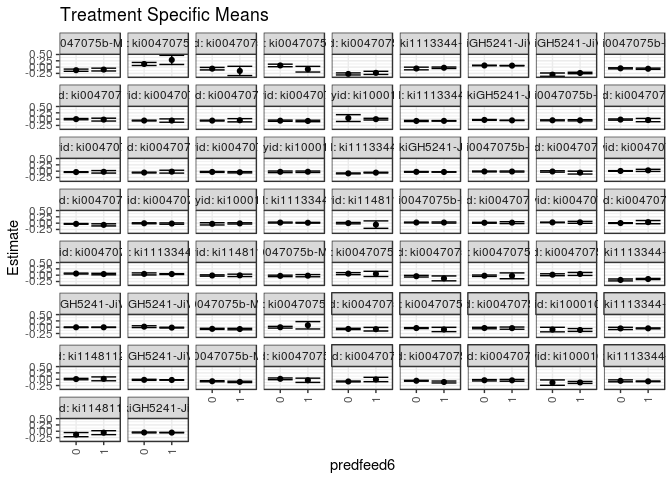

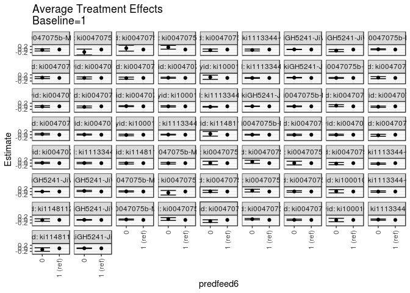

[figure not shown]

## Results Table

### Parameter: TSM

| agecat | studyid | country | intervention_level | baseline_level | estimate | ci_lower | ci_upper |
| --- | --- | --- | --- | --- | --- | --- | --- |
| 0-3 months | ki0047075b-MAL-ED | BANGLADESH | 1 | NA | -0.0980081 | -0.1537159 | -0.0423003 |
| 0-3 months | ki0047075b-MAL-ED | BANGLADESH | 0 | NA | -0.1227292 | -0.1662995 | -0.0791588 |
| 0-3 months | ki0047075b-MAL-ED | BRAZIL | 1 | NA | 0.2854366 | 0.1049419 | 0.4659314 |
| 0-3 months | ki0047075b-MAL-ED | BRAZIL | 0 | NA | 0.1239889 | 0.0634094 | 0.1845685 |
| 0-3 months | ki0047075b-MAL-ED | INDIA | 1 | NA | -0.1519059 | -0.3354979 | 0.0316861 |
| 0-3 months | ki0047075b-MAL-ED | INDIA | 0 | NA | -0.0618553 | -0.1121399 | -0.0115708 |
| 0-3 months | ki0047075b-MAL-ED | NEPAL | 1 | NA | -0.0832619 | -0.1953867 | 0.0288629 |
| 0-3 months | ki0047075b-MAL-ED | NEPAL | 0 | NA | 0.0658589 | 0.0158599 | 0.1158578 |
| 0-3 months | ki0047075b-MAL-ED | PERU | 1 | NA | -0.2282499 | -0.2908788 | -0.1656211 |
| 0-3 months | ki0047075b-MAL-ED | PERU | 0 | NA | -0.2709776 | -0.3122326 | -0.2297225 |
| 0-3 months | ki1113344-GMS-Nepal | NEPAL | 1 | NA | -0.0256666 | -0.0544550 | 0.0031218 |
| 0-3 months | ki1113344-GMS-Nepal | NEPAL | 0 | NA | -0.0554430 | -0.1088196 | -0.0020663 |
| 0-3 months | kiGH5241-JiVitA-3 | BANGLADESH | 1 | NA | 0.0584224 | 0.0518389 | 0.0650059 |
| 0-3 months | kiGH5241-JiVitA-3 | BANGLADESH | 0 | NA | 0.0641677 | 0.0531630 | 0.0751724 |
| 0-3 months | kiGH5241-JiVitA-4 | BANGLADESH | 1 | NA | -0.2332346 | -0.2620374 | -0.2044318 |
| 0-3 months | kiGH5241-JiVitA-4 | BANGLADESH | 0 | NA | -0.2987296 | -0.3636773 | -0.2337818 |
| 3-6 months | ki0047075b-MAL-ED | BANGLADESH | 1 | NA | -0.0196230 | -0.0634782 | 0.0242322 |
| 3-6 months | ki0047075b-MAL-ED | BANGLADESH | 0 | NA | -0.0272390 | -0.0560683 | 0.0015903 |
| 3-6 months | ki0047075b-MAL-ED | BRAZIL | 1 | NA | 0.0506321 | -0.0525160 | 0.1537802 |
| 3-6 months | ki0047075b-MAL-ED | BRAZIL | 0 | NA | 0.0613824 | 0.0219067 | 0.1008581 |
| 3-6 months | ki0047075b-MAL-ED | INDIA | 1 | NA | -0.1268472 | -0.2236942 | -0.0300002 |
| 3-6 months | ki0047075b-MAL-ED | INDIA | 0 | NA | -0.0408742 | -0.0728546 | -0.0088938 |
| 3-6 months | ki0047075b-MAL-ED | NEPAL | 1 | NA | -0.0248564 | -0.1409453 | 0.0912325 |
| 3-6 months | ki0047075b-MAL-ED | NEPAL | 0 | NA | -0.0217660 | -0.0503014 | 0.0067695 |
| 3-6 months | ki0047075b-MAL-ED | PERU | 1 | NA | 0.0485032 | -0.0104626 | 0.1074689 |
| 3-6 months | ki0047075b-MAL-ED | PERU | 0 | NA | 0.0184031 | -0.0194827 | 0.0562890 |
| 3-6 months | ki1113344-GMS-Nepal | NEPAL | 1 | NA | -0.1517680 | -0.1731902 | -0.1303458 |
| 3-6 months | ki1113344-GMS-Nepal | NEPAL | 0 | NA | -0.1891274 | -0.2270275 | -0.1512274 |
| 3-6 months | kiGH5241-JiVitA-3 | BANGLADESH | 1 | NA | -0.0036537 | -0.0106269 | 0.0033195 |
| 3-6 months | kiGH5241-JiVitA-3 | BANGLADESH | 0 | NA | -0.0033979 | -0.0148328 | 0.0080371 |

[output cut: 100 more lines]

### Parameter: E(Y)

| agecat | studyid | country | intervention_level | baseline_level | estimate | ci_lower | ci_upper |
| --- | --- | --- | --- | --- | --- | --- | --- |
| 0-3 months | ki0047075b-MAL-ED | BANGLADESH | NA | NA | -0.1184816 | -0.1534627 | -0.0835006 |
| 0-3 months | ki0047075b-MAL-ED | BRAZIL | NA | NA | 0.1446583 | 0.0870976 | 0.2022191 |
| 0-3 months | ki0047075b-MAL-ED | INDIA | NA | NA | -0.0661691 | -0.1149338 | -0.0174045 |
| 0-3 months | ki0047075b-MAL-ED | NEPAL | NA | NA | 0.0549995 | 0.0083296 | 0.1016694 |
| 0-3 months | ki0047075b-MAL-ED | PERU | NA | NA | -0.2591669 | -0.2929238 | -0.2254100 |
| 0-3 months | ki1113344-GMS-Nepal | NEPAL | NA | NA | -0.0320017 | -0.0574984 | -0.0065051 |
| 0-3 months | kiGH5241-JiVitA-3 | BANGLADESH | NA | NA | 0.0596909 | 0.0535305 | 0.0658514 |
| 0-3 months | kiGH5241-JiVitA-4 | BANGLADESH | NA | NA | -0.2441243 | -0.2705116 | -0.2177371 |
| 3-6 months | ki0047075b-MAL-ED | BANGLADESH | NA | NA | -0.0242637 | -0.0483310 | -0.0001965 |
| 3-6 months | ki0047075b-MAL-ED | BRAZIL | NA | NA | 0.0597292 | 0.0232017 | 0.0962566 |
| 3-6 months | ki0047075b-MAL-ED | INDIA | NA | NA | -0.0402849 | -0.0709914 | -0.0095783 |
| 3-6 months | ki0047075b-MAL-ED | NEPAL | NA | NA | -0.0219437 | -0.0494813 | 0.0055938 |
| 3-6 months | ki0047075b-MAL-ED | PERU | NA | NA | 0.0265214 | -0.0048238 | 0.0578666 |
| 3-6 months | ki1113344-GMS-Nepal | NEPAL | NA | NA | -0.1617717 | -0.1805409 | -0.1430025 |
| 3-6 months | kiGH5241-JiVitA-3 | BANGLADESH | NA | NA | -0.0036992 | -0.0098266 | 0.0024282 |
| 3-6 months | kiGH5241-JiVitA-4 | BANGLADESH | NA | NA | -0.0106594 | -0.0245209 | 0.0032020 |
| 6-9 months | ki0047075b-MAL-ED | BANGLADESH | NA | NA | -0.0677541 | -0.0853832 | -0.0501249 |
| 6-9 months | ki0047075b-MAL-ED | BRAZIL | NA | NA | 0.0087834 | -0.0260798 | 0.0436466 |
| 6-9 months | ki0047075b-MAL-ED | INDIA | NA | NA | -0.0688970 | -0.0921281 | -0.0456658 |
| 6-9 months | ki0047075b-MAL-ED | NEPAL | NA | NA | -0.0368585 | -0.0562650 | -0.0174521 |
| 6-9 months | ki0047075b-MAL-ED | PERU | NA | NA | -0.0335784 | -0.0576919 | -0.0094649 |
| 6-9 months | ki1000109-EE | PAKISTAN | NA | NA | -0.1084252 | -0.1595142 | -0.0573361 |
| 6-9 months | ki1113344-GMS-Nepal | NEPAL | NA | NA | -0.0453626 | -0.0630368 | -0.0276885 |
| 6-9 months | ki1148112-LCNI-5 | MALAWI | NA | NA | 0.0095862 | -0.0174314 | 0.0366037 |
| 6-9 months | kiGH5241-JiVitA-4 | BANGLADESH | NA | NA | -0.0285987 | -0.0378556 | -0.0193419 |
| 9-12 months | ki0047075b-MAL-ED | BANGLADESH | NA | NA | -0.0895925 | -0.1058429 | -0.0733421 |
| 9-12 months | ki0047075b-MAL-ED | BRAZIL | NA | NA | 0.0081784 | -0.0226414 | 0.0389982 |
| 9-12 months | ki0047075b-MAL-ED | INDIA | NA | NA | -0.0907785 | -0.1072717 | -0.0742853 |
| 9-12 months | ki0047075b-MAL-ED | NEPAL | NA | NA | -0.0633531 | -0.0808095 | -0.0458966 |
| 9-12 months | ki0047075b-MAL-ED | PERU | NA | NA | -0.0419261 | -0.0633861 | -0.0204661 |
| 9-12 months | ki1000109-EE | PAKISTAN | NA | NA | -0.1284364 | -0.1649203 | -0.0919525 |
| 9-12 months | ki1113344-GMS-Nepal | NEPAL | NA | NA | -0.0795850 | -0.0935763 | -0.0655937 |
| 9-12 months | ki1148112-LCNI-5 | MALAWI | NA | NA | -0.1052774 | -0.1637460 | -0.0468087 |
| 9-12 months | kiGH5241-JiVitA-4 | BANGLADESH | NA | NA | -0.0529092 | -0.0609759 | -0.0448426 |
| 12-15 months | ki0047075b-MAL-ED | BANGLADESH | NA | NA | -0.0539793 | -0.0699671 | -0.0379916 |
| 12-15 months | ki0047075b-MAL-ED | BRAZIL | NA | NA | -0.0030430 | -0.0256176 | 0.0195316 |
| 12-15 months | ki0047075b-MAL-ED | INDIA | NA | NA | -0.0564380 | -0.0722459 | -0.0406302 |
| 12-15 months | ki0047075b-MAL-ED | NEPAL | NA | NA | -0.0581047 | -0.0738902 | -0.0423192 |
| 12-15 months | ki0047075b-MAL-ED | PERU | NA | NA | -0.0653532 | -0.0832313 | -0.0474751 |
| 12-15 months | ki1000109-EE | PAKISTAN | NA | NA | 0.0041770 | -0.0299533 | 0.0383073 |
| 12-15 months | ki1113344-GMS-Nepal | NEPAL | NA | NA | -0.0700044 | -0.0796323 | -0.0603764 |
| 12-15 months | kiGH5241-JiVitA-4 | BANGLADESH | NA | NA | -0.0457929 | -0.0524470 | -0.0391387 |
| 15-18 months | ki0047075b-MAL-ED | BANGLADESH | NA | NA | -0.0465524 | -0.0603507 | -0.0327542 |
| 15-18 months | ki0047075b-MAL-ED | BRAZIL | NA | NA | -0.0203422 | -0.0414264 | 0.0007419 |
| 15-18 months | ki0047075b-MAL-ED | INDIA | NA | NA | -0.0368191 | -0.0499234 | -0.0237147 |
| 15-18 months | ki0047075b-MAL-ED | NEPAL | NA | NA | -0.0540981 | -0.0695896 | -0.0386065 |
| 15-18 months | ki0047075b-MAL-ED | PERU | NA | NA | -0.0360565 | -0.0515481 | -0.0205649 |
| 15-18 months | ki1000109-EE | PAKISTAN | NA | NA | -0.0244177 | -0.0490831 | 0.0002477 |
| 15-18 months | ki1113344-GMS-Nepal | NEPAL | NA | NA | -0.0665082 | -0.0782160 | -0.0548005 |
| 15-18 months | kiGH5241-JiVitA-4 | BANGLADESH | NA | NA | -0.0322067 | -0.0387357 | -0.0256778 |
| 18-21 months | ki0047075b-MAL-ED | BANGLADESH | NA | NA | -0.0136918 | -0.0255600 | -0.0018237 |
| 18-21 months | ki0047075b-MAL-ED | BRAZIL | NA | NA | -0.0203590 | -0.0449122 | 0.0041942 |
| 18-21 months | ki0047075b-MAL-ED | INDIA | NA | NA | 0.0056606 | -0.0059781 | 0.0172993 |
| 18-21 months | ki0047075b-MAL-ED | NEPAL | NA | NA | -0.0305803 | -0.0437450 | -0.0174157 |
| 18-21 months | ki0047075b-MAL-ED | PERU | NA | NA | -0.0081141 | -0.0233572 | 0.0071290 |
| 18-21 months | ki1000109-EE | PAKISTAN | NA | NA | -0.0119733 | -0.0348121 | 0.0108655 |
| 18-21 months | ki1113344-GMS-Nepal | NEPAL | NA | NA | 0.0165107 | 0.0043866 | 0.0286347 |
| 18-21 months | ki1148112-LCNI-5 | MALAWI | NA | NA | -0.0092283 | -0.0423286 | 0.0238719 |
| 21-24 months | ki0047075b-MAL-ED | BANGLADESH | NA | NA | 0.0256240 | 0.0132472 | 0.0380008 |
| 21-24 months | ki0047075b-MAL-ED | BRAZIL | NA | NA | 0.0164870 | 0.0004862 | 0.0324878 |
| 21-24 months | ki0047075b-MAL-ED | INDIA | NA | NA | 0.0308252 | 0.0194990 | 0.0421515 |
| 21-24 months | ki0047075b-MAL-ED | NEPAL | NA | NA | 0.0061413 | -0.0078495 | 0.0201321 |
| 21-24 months | ki0047075b-MAL-ED | PERU | NA | NA | 0.0569744 | 0.0416628 | 0.0722859 |
| 21-24 months | ki1113344-GMS-Nepal | NEPAL | NA | NA | 0.0465624 | 0.0306829 | 0.0624420 |
| 21-24 months | ki1148112-LCNI-5 | MALAWI | NA | NA | -0.0116248 | -0.0336145 | 0.0103649 |

### Parameter: ATE

| agecat | studyid | country | intervention_level | baseline_level | estimate | ci_lower | ci_upper |
| --- | --- | --- | --- | --- | --- | --- | --- |
| 0-3 months | ki0047075b-MAL-ED | BANGLADESH | 1 | 1 | 0.0000000 | 0.0000000 | 0.0000000 |
| 0-3 months | ki0047075b-MAL-ED | BANGLADESH | 0 | 1 | -0.0247211 | -0.0940700 | 0.0446279 |
| 0-3 months | ki0047075b-MAL-ED | BRAZIL | 1 | 1 | 0.0000000 | 0.0000000 | 0.0000000 |
| 0-3 months | ki0047075b-MAL-ED | BRAZIL | 0 | 1 | -0.1614477 | -0.3522131 | 0.0293177 |
| 0-3 months | ki0047075b-MAL-ED | INDIA | 1 | 1 | 0.0000000 | 0.0000000 | 0.0000000 |
| 0-3 months | ki0047075b-MAL-ED | INDIA | 0 | 1 | 0.0900506 | -0.1003032 | 0.2804044 |
| 0-3 months | ki0047075b-MAL-ED | NEPAL | 1 | 1 | 0.0000000 | 0.0000000 | 0.0000000 |
| 0-3 months | ki0047075b-MAL-ED | NEPAL | 0 | 1 | 0.1491208 | 0.0258930 | 0.2723486 |
| 0-3 months | ki0047075b-MAL-ED | PERU | 1 | 1 | 0.0000000 | 0.0000000 | 0.0000000 |
| 0-3 months | ki0047075b-MAL-ED | PERU | 0 | 1 | -0.0427276 | -0.1192108 | 0.0337555 |
| 0-3 months | ki1113344-GMS-Nepal | NEPAL | 1 | 1 | 0.0000000 | 0.0000000 | 0.0000000 |
| 0-3 months | ki1113344-GMS-Nepal | NEPAL | 0 | 1 | -0.0297764 | -0.0902829 | 0.0307302 |
| 0-3 months | kiGH5241-JiVitA-3 | BANGLADESH | 1 | 1 | 0.0000000 | 0.0000000 | 0.0000000 |
| 0-3 months | kiGH5241-JiVitA-3 | BANGLADESH | 0 | 1 | 0.0057453 | -0.0057006 | 0.0171912 |
| 0-3 months | kiGH5241-JiVitA-4 | BANGLADESH | 1 | 1 | 0.0000000 | 0.0000000 | 0.0000000 |
| 0-3 months | kiGH5241-JiVitA-4 | BANGLADESH | 0 | 1 | -0.0654949 | -0.1362108 | 0.0052210 |
| 3-6 months | ki0047075b-MAL-ED | BANGLADESH | 1 | 1 | 0.0000000 | 0.0000000 | 0.0000000 |
| 3-6 months | ki0047075b-MAL-ED | BANGLADESH | 0 | 1 | -0.0076160 | -0.0606675 | 0.0454355 |
| 3-6 months | ki0047075b-MAL-ED | BRAZIL | 1 | 1 | 0.0000000 | 0.0000000 | 0.0000000 |
| 3-6 months | ki0047075b-MAL-ED | BRAZIL | 0 | 1 | 0.0107503 | -0.0997082 | 0.1212089 |
| 3-6 months | ki0047075b-MAL-ED | INDIA | 1 | 1 | 0.0000000 | 0.0000000 | 0.0000000 |
| 3-6 months | ki0047075b-MAL-ED | INDIA | 0 | 1 | 0.0859730 | -0.0157860 | 0.1877320 |
| 3-6 months | ki0047075b-MAL-ED | NEPAL | 1 | 1 | 0.0000000 | 0.0000000 | 0.0000000 |
| 3-6 months | ki0047075b-MAL-ED | NEPAL | 0 | 1 | 0.0030904 | -0.1164234 | 0.1226043 |
| 3-6 months | ki0047075b-MAL-ED | PERU | 1 | 1 | 0.0000000 | 0.0000000 | 0.0000000 |
| 3-6 months | ki0047075b-MAL-ED | PERU | 0 | 1 | -0.0301000 | -0.1002260 | 0.0400259 |
| 3-6 months | ki1113344-GMS-Nepal | NEPAL | 1 | 1 | 0.0000000 | 0.0000000 | 0.0000000 |
| 3-6 months | ki1113344-GMS-Nepal | NEPAL | 0 | 1 | -0.0373594 | -0.0808686 | 0.0061498 |
| 3-6 months | kiGH5241-JiVitA-3 | BANGLADESH | 1 | 1 | 0.0000000 | 0.0000000 | 0.0000000 |
| 3-6 months | kiGH5241-JiVitA-3 | BANGLADESH | 0 | 1 | 0.0002558 | -0.0127486 | 0.0132603 |

[output cut: 100 more lines]

### Parameter: PAR

| agecat | studyid | country | intervention_level | baseline_level | estimate | ci_lower | ci_upper |
| --- | --- | --- | --- | --- | --- | --- | --- |
| 0-3 months | ki0047075b-MAL-ED | BANGLADESH | 1 | NA | -0.0204735 | -0.0661930 | 0.0252460 |
| 0-3 months | ki0047075b-MAL-ED | BRAZIL | 1 | NA | -0.1407783 | -0.3085912 | 0.0270346 |
| 0-3 months | ki0047075b-MAL-ED | INDIA | 1 | NA | 0.0857368 | -0.0955219 | 0.2669954 |
| 0-3 months | ki0047075b-MAL-ED | NEPAL | 1 | NA | 0.1382614 | 0.0224047 | 0.2541181 |
| 0-3 months | ki0047075b-MAL-ED | PERU | 1 | NA | -0.0309170 | -0.0822887 | 0.0204548 |
| 0-3 months | ki1113344-GMS-Nepal | NEPAL | 1 | NA | -0.0063352 | -0.0223104 | 0.0096401 |
| 0-3 months | kiGH5241-JiVitA-3 | BANGLADESH | 1 | NA | 0.0012685 | -0.0013187 | 0.0038557 |
| 0-3 months | kiGH5241-JiVitA-4 | BANGLADESH | 1 | NA | -0.0108897 | -0.0220229 | 0.0002436 |
| 3-6 months | ki0047075b-MAL-ED | BANGLADESH | 1 | NA | -0.0046408 | -0.0389997 | 0.0297182 |
| 3-6 months | ki0047075b-MAL-ED | BRAZIL | 1 | NA | 0.0090971 | -0.0860227 | 0.1042169 |
| 3-6 months | ki0047075b-MAL-ED | INDIA | 1 | NA | 0.0865623 | -0.0099626 | 0.1830872 |
| 3-6 months | ki0047075b-MAL-ED | NEPAL | 1 | NA | 0.0029127 | -0.1118902 | 0.1177155 |
| 3-6 months | ki0047075b-MAL-ED | PERU | 1 | NA | -0.0219818 | -0.0698764 | 0.0259129 |
| 3-6 months | ki1113344-GMS-Nepal | NEPAL | 1 | NA | -0.0100037 | -0.0219340 | 0.0019266 |
| 3-6 months | kiGH5241-JiVitA-3 | BANGLADESH | 1 | NA | -0.0000455 | -0.0030813 | 0.0029904 |
| 3-6 months | kiGH5241-JiVitA-4 | BANGLADESH | 1 | NA | 0.0059877 | 0.0000663 | 0.0119091 |
| 6-9 months | ki0047075b-MAL-ED | BANGLADESH | 1 | NA | 0.0046767 | -0.0196899 | 0.0290433 |
| 6-9 months | ki0047075b-MAL-ED | BRAZIL | 1 | NA | -0.0676811 | -0.1974780 | 0.0621159 |
| 6-9 months | ki0047075b-MAL-ED | INDIA | 1 | NA | 0.0102579 | -0.0620642 | 0.0825799 |
| 6-9 months | ki0047075b-MAL-ED | NEPAL | 1 | NA | 0.0535610 | -0.0304680 | 0.1375901 |
| 6-9 months | ki0047075b-MAL-ED | PERU | 1 | NA | 0.0031180 | -0.0309370 | 0.0371731 |
| 6-9 months | ki1000109-EE | PAKISTAN | 1 | NA | 0.0018109 | -0.0100293 | 0.0136512 |
| 6-9 months | ki1113344-GMS-Nepal | NEPAL | 1 | NA | 0.0001167 | -0.0117335 | 0.0119669 |
| 6-9 months | ki1148112-LCNI-5 | MALAWI | 1 | NA | -0.0061900 | -0.0752043 | 0.0628243 |
| 6-9 months | kiGH5241-JiVitA-4 | BANGLADESH | 1 | NA | 0.0010132 | -0.0035986 | 0.0056250 |
| 9-12 months | ki0047075b-MAL-ED | BANGLADESH | 1 | NA | 0.0157324 | -0.0055133 | 0.0369780 |
| 9-12 months | ki0047075b-MAL-ED | BRAZIL | 1 | NA | 0.0500379 | -0.0298474 | 0.1299233 |
| 9-12 months | ki0047075b-MAL-ED | INDIA | 1 | NA | -0.0806110 | -0.1648982 | 0.0036761 |
| 9-12 months | ki0047075b-MAL-ED | NEPAL | 1 | NA | 0.0468738 | 0.0064217 | 0.0873260 |
| 9-12 months | ki0047075b-MAL-ED | PERU | 1 | NA | 0.0021025 | -0.0272398 | 0.0314448 |
| 9-12 months | ki1000109-EE | PAKISTAN | 1 | NA | -0.0008009 | -0.0137388 | 0.0121370 |
| 9-12 months | ki1113344-GMS-Nepal | NEPAL | 1 | NA | 0.0040684 | -0.0052718 | 0.0134086 |
| 9-12 months | ki1148112-LCNI-5 | MALAWI | 1 | NA | -0.0491444 | -0.1251887 | 0.0268999 |
| 9-12 months | kiGH5241-JiVitA-4 | BANGLADESH | 1 | NA | 0.0008766 | -0.0031989 | 0.0049521 |
| 12-15 months | ki0047075b-MAL-ED | BANGLADESH | 1 | NA | 0.0113754 | -0.0099153 | 0.0326661 |
| 12-15 months | ki0047075b-MAL-ED | BRAZIL | 1 | NA | 0.0165077 | -0.0361623 | 0.0691776 |
| 12-15 months | ki0047075b-MAL-ED | INDIA | 1 | NA | 0.0007591 | -0.0637554 | 0.0652735 |
| 12-15 months | ki0047075b-MAL-ED | NEPAL | 1 | NA | -0.0137430 | -0.0765690 | 0.0490830 |
| 12-15 months | ki0047075b-MAL-ED | PERU | 1 | NA | 0.0074539 | -0.0175760 | 0.0324838 |
| 12-15 months | ki1000109-EE | PAKISTAN | 1 | NA | 0.0058532 | -0.0135283 | 0.0252347 |
| 12-15 months | ki1113344-GMS-Nepal | NEPAL | 1 | NA | -0.0004428 | -0.0063618 | 0.0054762 |
| 12-15 months | kiGH5241-JiVitA-4 | BANGLADESH | 1 | NA | 0.0037241 | -0.0000857 | 0.0075338 |
| 15-18 months | ki0047075b-MAL-ED | BANGLADESH | 1 | NA | 0.0010108 | -0.0183522 | 0.0203739 |
| 15-18 months | ki0047075b-MAL-ED | BRAZIL | 1 | NA | 0.0169806 | -0.0422582 | 0.0762193 |
| 15-18 months | ki0047075b-MAL-ED | INDIA | 1 | NA | -0.0102272 | -0.0596416 | 0.0391872 |
| 15-18 months | ki0047075b-MAL-ED | NEPAL | 1 | NA | -0.0334160 | -0.0893891 | 0.0225570 |
| 15-18 months | ki0047075b-MAL-ED | PERU | 1 | NA | 0.0081760 | -0.0119068 | 0.0282588 |
| 15-18 months | ki1000109-EE | PAKISTAN | 1 | NA | -0.0004246 | -0.0067606 | 0.0059113 |
| 15-18 months | ki1113344-GMS-Nepal | NEPAL | 1 | NA | -0.0070246 | -0.0125709 | -0.0014783 |
| 15-18 months | kiGH5241-JiVitA-4 | BANGLADESH | 1 | NA | 0.0011161 | -0.0021217 | 0.0043538 |
| 18-21 months | ki0047075b-MAL-ED | BANGLADESH | 1 | NA | 0.0015659 | -0.0153513 | 0.0184830 |
| 18-21 months | ki0047075b-MAL-ED | BRAZIL | 1 | NA | 0.0377903 | -0.0165038 | 0.0920844 |
| 18-21 months | ki0047075b-MAL-ED | INDIA | 1 | NA | -0.0253318 | -0.0676108 | 0.0169472 |
| 18-21 months | ki0047075b-MAL-ED | NEPAL | 1 | NA | 0.0371084 | -0.0054297 | 0.0796466 |
| 18-21 months | ki0047075b-MAL-ED | PERU | 1 | NA | 0.0076880 | -0.0146262 | 0.0300023 |
| 18-21 months | ki1000109-EE | PAKISTAN | 1 | NA | -0.0026098 | -0.0106230 | 0.0054034 |
| 18-21 months | ki1113344-GMS-Nepal | NEPAL | 1 | NA | 0.0007068 | -0.0054301 | 0.0068437 |
| 18-21 months | ki1148112-LCNI-5 | MALAWI | 1 | NA | 0.0487128 | -0.0767841 | 0.1742097 |
| 21-24 months | ki0047075b-MAL-ED | BANGLADESH | 1 | NA | 0.0008388 | -0.0161618 | 0.0178394 |
| 21-24 months | ki0047075b-MAL-ED | BRAZIL | 1 | NA | -0.0044563 | -0.0394119 | 0.0304992 |
| 21-24 months | ki0047075b-MAL-ED | INDIA | 1 | NA | -0.0021236 | -0.0405583 | 0.0363111 |
| 21-24 months | ki0047075b-MAL-ED | NEPAL | 1 | NA | -0.0343239 | -0.0958911 | 0.0272432 |
| 21-24 months | ki0047075b-MAL-ED | PERU | 1 | NA | 0.0119612 | -0.0127014 | 0.0366238 |
| 21-24 months | ki1113344-GMS-Nepal | NEPAL | 1 | NA | 0.0012077 | -0.0090362 | 0.0114515 |
| 21-24 months | ki1148112-LCNI-5 | MALAWI | 1 | NA | -0.0042831 | -0.0493678 | 0.0408016 |